# Bellabet Project

Ogheneovo

2023-04-21

### Loading libraries

```r
library("tidyverse")
library("skimr")
library("janitor")
```

```r
library("dplyr")
library("ggplot2")
library("ggpubr")
library(ggcorrplot)
```

### Loading data (csv file) into r

```r
daily_activity <- read_csv("Fitabase Data 4.12.16-5.12.16/dailyActivity_merged.csv")
heartrate <- read_csv("Fitabase Data 4.12.16-5.12.16/heartrate_seconds_merged.csv")
sleepday <- read_csv("Fitabase Data 4.12.16-5.12.16/sleepDay_merged.csv")
weightlog_info <- read_csv("Fitabase Data 4.12.16-5.12.16/weightLogInfo_merged.csv")
```

### Viewing and Cleaning Data

```r
head(daily_activity)
```

```
## # A tibble: 6 × 15
##       Id Activ…¹ Total…² Total…³ Track…⁴ Logge…⁵ VeryA…⁶ Moder…⁷ Light…⁸ Seden…⁹
##    <dbl> <chr>     <dbl>   <dbl>   <dbl>   <dbl>   <dbl>   <dbl>   <dbl>   <dbl>
## 1 1.50e9 4/12/2…   13162    8.5     8.5        0    1.88   0.550    6.06       0
## 2 1.50e9 4/13/2…   10735    6.97    6.97       0    1.57   0.690    4.71       0
## 3 1.50e9 4/14/2…   10460    6.74    6.74       0    2.44   0.400    3.91       0
## 4 1.50e9 4/15/2…    9762    6.28    6.28       0    2.14   1.26     2.83       0
## 5 1.50e9 4/16/2…   12669    8.16    8.16       0    2.71   0.410    5.04       0
## 6 1.50e9 4/17/2…    9705    6.48    6.48       0    3.19   0.780    2.51       0
## # … with 5 more variables: VeryActiveMinutes <dbl>, FairlyActiveMinutes <dbl>,
## #   LightlyActiveMinutes <dbl>, SedentaryMinutes <dbl>, Calories <dbl>, and
## #   abbreviated variable names ¹ActivityDate, ²TotalSteps, ³TotalDistance,
## #   ⁴TrackerDistance, ⁵LoggedActivitiesDistance, ⁶VeryActiveDistance,
## #   ⁷ModeratelyActiveDistance, ⁸LightActiveDistance, ⁹SedentaryActiveDistance
```

```r
head(heartrate)
```

```
## # A tibble: 6 × 3
##           Id Time                 Value
##        <dbl> <chr>                <dbl>
## 1 2022484408 4/12/2016 7:21:00 AM    97
## 2 2022484408 4/12/2016 7:21:05 AM   102
## 3 2022484408 4/12/2016 7:21:10 AM   105
## 4 2022484408 4/12/2016 7:21:20 AM   103
## 5 2022484408 4/12/2016 7:21:25 AM   101
## 6 2022484408 4/12/2016 7:22:05 AM    95
```

```r
head(sleepday)
```

```
## # A tibble: 6 × 5
##           Id SleepDay              TotalSleepRecords TotalMinutesAsleep TotalT…¹
##        <dbl> <chr>                             <dbl>              <dbl>    <dbl>
## 1 1503960366 4/12/2016 12:00:00 AM                 1                327      346
## 2 1503960366 4/13/2016 12:00:00 AM                 2                384      407
## 3 1503960366 4/15/2016 12:00:00 AM                 1                412      442
## 4 1503960366 4/16/2016 12:00:00 AM                 2                340      367
## 5 1503960366 4/17/2016 12:00:00 AM                 1                700      712
## 6 1503960366 4/19/2016 12:00:00 AM                 1                304      320
## # … with abbreviated variable name ¹TotalTimeInBed
```

```r
head(weightlog_info)
```

```
## # A tibble: 6 × 8
##           Id Date                  WeightKg Weight…¹   Fat   BMI IsMan…²   LogId
##        <dbl> <chr>                    <dbl>    <dbl> <dbl> <dbl> <lgl>     <dbl>
## 1 1503960366 5/2/2016 11:59:59 PM      52.6     116.    22  22.6 TRUE    1.46e12
## 2 1503960366 5/3/2016 11:59:59 PM      52.6     116.    NA  22.6 TRUE    1.46e12
## 3 1927972279 4/13/2016 1:08:52 AM     134.      294.    NA  47.5 FALSE   1.46e12
## 4 2873212765 4/21/2016 11:59:59 PM     56.7     125.    NA  21.5 TRUE    1.46e12
## 5 2873212765 5/12/2016 11:59:59 PM     57.3     126.    NA  21.7 TRUE    1.46e12
## 6 4319703577 4/17/2016 11:59:59 PM     72.4     160.    25  27.5 TRUE    1.46e12
## # … with abbreviated variable names ¹WeightPounds, ²IsManualReport
```

### Getting the column names

```r
colnames(daily_activity)
```

```
##  [1] "Id"                       "ActivityDate"
##  [3] "TotalSteps"               "TotalDistance"
##  [5] "TrackerDistance"          "LoggedActivitiesDistance"
##  [7] "VeryActiveDistance"       "ModeratelyActiveDistance"
##  [9] "LightActiveDistance"      "SedentaryActiveDistance"
## [11] "VeryActiveMinutes"        "FairlyActiveMinutes"
## [13] "LightlyActiveMinutes"     "SedentaryMinutes"
## [15] "Calories"
```

```r
colnames(heartrate)
```

```
## [1] "Id"    "Time"  "Value"
```

```r
colnames(sleepday)
```

```
## [1] "Id"                 "SleepDay"           "TotalSleepRecords"
## [4] "TotalMinutesAsleep" "TotalTimeInBed"
```

```r
colnames(weightlog_info)
```

```
## [1] "Id"             "Date"           "WeightKg"       "WeightPounds"
## [5] "Fat"            "BMI"            "IsManualReport" "LogId"
```

### Checking for the number of columns, rows and datatype()

```r
glimpse(daily_activity)
```

```
## Rows: 940
## Columns: 15
## $ Id                       <dbl> 1503960366, 1503960366, 1503960366, 150396036…
## $ ActivityDate             <chr> "4/12/2016", "4/13/2016", "4/14/2016", "4/15/…
## $ TotalSteps               <dbl> 13162, 10735, 10460, 9762, 12669, 9705, 13019…
## $ TotalDistance            <dbl> 8.50, 6.97, 6.74, 6.28, 8.16, 6.48, 8.59, 9.8…
## $ TrackerDistance          <dbl> 8.50, 6.97, 6.74, 6.28, 8.16, 6.48, 8.59, 9.8…
## $ LoggedActivitiesDistance <dbl> 0, 0, 0, 0, 0, 0, 0, 0, 0, 0, 0, 0, 0, 0, 0, …
## $ VeryActiveDistance       <dbl> 1.88, 1.57, 2.44, 2.14, 2.71, 3.19, 3.25, 3.5…
## $ ModeratelyActiveDistance <dbl> 0.55, 0.69, 0.40, 1.26, 0.41, 0.78, 0.64, 1.3…
## $ LightActiveDistance      <dbl> 6.06, 4.71, 3.91, 2.83, 5.04, 2.51, 4.71, 5.0…
## $ SedentaryActiveDistance  <dbl> 0, 0, 0, 0, 0, 0, 0, 0, 0, 0, 0, 0, 0, 0, 0, …
## $ VeryActiveMinutes        <dbl> 25, 21, 30, 29, 36, 38, 42, 50, 28, 19, 66, 4…
## $ FairlyActiveMinutes      <dbl> 13, 19, 11, 34, 10, 20, 16, 31, 12, 8, 27, 21…
## $ LightlyActiveMinutes     <dbl> 328, 217, 181, 209, 221, 164, 233, 264, 205, …
## $ SedentaryMinutes         <dbl> 728, 776, 1218, 726, 773, 539, 1149, 775, 818…
## $ Calories                 <dbl> 1985, 1797, 1776, 1745, 1863, 1728, 1921, 203…
```

```r
glimpse(heartrate)
```

```
## Rows: 2,483,658
## Columns: 3
## $ Id    <dbl> 2022484408, 2022484408, 2022484408, 2022484408, 2022484408, 2022…
## $ Time  <chr> "4/12/2016 7:21:00 AM", "4/12/2016 7:21:05 AM", "4/12/2016 7:21:…
## $ Value <dbl> 97, 102, 105, 103, 101, 95, 91, 93, 94, 93, 92, 89, 83, 61, 60, …
```

```r
glimpse(sleepday)
```

```
## Rows: 413
## Columns: 5
## $ Id                 <dbl> 1503960366, 1503960366, 1503960366, 1503960366, 150…
## $ SleepDay           <chr> "4/12/2016 12:00:00 AM", "4/13/2016 12:00:00 AM", "…
## $ TotalSleepRecords  <dbl> 1, 2, 1, 2, 1, 1, 1, 1, 1, 1, 1, 1, 1, 1, 1, 1, 1, …
## $ TotalMinutesAsleep <dbl> 327, 384, 412, 340, 700, 304, 360, 325, 361, 430, 2…
## $ TotalTimeInBed     <dbl> 346, 407, 442, 367, 712, 320, 377, 364, 384, 449, 3…
```

```r
glimpse(weightlog_info)
```

```
## Rows: 67
## Columns: 8
## $ Id             <dbl> 1503960366, 1503960366, 1927972279, 2873212765, 2873212…
## $ Date           <chr> "5/2/2016 11:59:59 PM", "5/3/2016 11:59:59 PM", "4/13/2…
## $ WeightKg       <dbl> 52.6, 52.6, 133.5, 56.7, 57.3, 72.4, 72.3, 69.7, 70.3, …
## $ WeightPounds   <dbl> 115.9631, 115.9631, 294.3171, 125.0021, 126.3249, 159.6…
## $ Fat            <dbl> 22, NA, NA, NA, NA, 25, NA, NA, NA, NA, NA, NA, NA, NA,…
## $ BMI            <dbl> 22.65, 22.65, 47.54, 21.45, 21.69, 27.45, 27.38, 27.25,…
## $ IsManualReport <lgl> TRUE, TRUE, FALSE, TRUE, TRUE, TRUE, TRUE, TRUE, TRUE, …
## $ LogId          <dbl> 1.462234e+12, 1.462320e+12, 1.460510e+12, 1.461283e+12,…
```

### Check for missing values and duplicates

```r
print ("Count of missing variables - ")
```

```
## [1] "Count of missing variables - "
```

```r
sum(is.na(daily_activity))
```

```
## [1] 0
```

```r
print(" Count of Duplicate values - ")
```

```
## [1] " Count of Duplicate values - "
```

```r
sum(duplicated(daily_activity))
```

```
## [1] 0
```

```r
print ("Count of missing variables - ")
```

```
## [1] "Count of missing variables - "
```

```r
sum(is.na(heartrate))
```

```
## [1] 0
```

```r
print(" Count of Duplicate values - ")
```

```
## [1] " Count of Duplicate values - "
```

```r
sum(duplicated(heartrate))
```

```
## [1] 0
```

```r
print ("Count of missing variables - ")
```

```
## [1] "Count of missing variables - "
```

```r
sum(is.na(sleepday))
```

```
## [1] 0
```

```r
print(" Count of Duplicate values - ")
```

```
## [1] " Count of Duplicate values - "
```

```r
sum(duplicated(sleepday))
```

```
## [1] 3
```

### Removing duplicate rows from the sleepday dataset

```r
sleepday <- sleepday %>% distinct()
print ("Count of missing variables - ")
```

```
## [1] "Count of missing variables - "
```

```r
sum(is.na(sleepday))
```

```
## [1] 0
```

```r
print(" Count of Duplicate values - ")
```

```
## [1] " Count of Duplicate values - "
```

```r
sum(duplicated(sleepday))
```

```
## [1] 0
```

```r
print ("Count of missing variables - ")
```

```
## [1] "Count of missing variables - "
```

```r
sum(is.na(weightlog_info))
```

```
## [1] 65
```

```r
print(" Count of Duplicate values - ")
```

```
## [1] " Count of Duplicate values - "
```

```r
sum(duplicated(weightlog_info))
```

```
## [1] 0
```

### Check to confirm rows with NA values and decide if we remove them or create a new df

```r
colSums(is.na(weightlog_info))
```

```
##             Id           Date       WeightKg   WeightPounds            Fat
##              0              0              0              0             65
##            BMI IsManualReport          LogId
##              0              0              0
```

*The fat column contains 65 NA values out of 67 entries. We will need to remove the fat column as it’s not useful to our analysis.*

### Removing the NA column from our weightlog_info dataset

```r
weightlog_info <- weightlog_info[,-5]
colSums(is.na(weightlog_info))
```

```
##             Id           Date       WeightKg   WeightPounds            BMI
##              0              0              0              0              0
## IsManualReport          LogId
##              0              0
```

## Processing Data

### Seperating columns having data & time for the different dataset so as to get unifomity of date

```r
heartrate <- separate(heartrate, Time, into = c('Date', 'Time'), sep = ' ')
heartrate <- heartrate %>% select(-Time)
```

```r
sleepday <- separate(sleepday, SleepDay, into = c('Date', 'Time'), sep = ' ')
sleepday <- sleepday %>% select(-Time)
```

```r
weightlog_info <- separate(weightlog_info, Date, into = c('Date', 'Time'), sep = ' ')
weightlog_info <- weightlog_info %>% select(-Time)
```

### Renaming the ActivityDate column from daily_activity dataset so as to harmonize the names

```r
daily_activity <- daily_activity %>% rename(Date = ActivityDate)
```

### Checking for columns names

```r
colnames(daily_activity)
```

```
##  [1] "Id"                       "Date"
##  [3] "TotalSteps"               "TotalDistance"
##  [5] "TrackerDistance"          "LoggedActivitiesDistance"
##  [7] "VeryActiveDistance"       "ModeratelyActiveDistance"
##  [9] "LightActiveDistance"      "SedentaryActiveDistance"
## [11] "VeryActiveMinutes"        "FairlyActiveMinutes"
## [13] "LightlyActiveMinutes"     "SedentaryMinutes"
## [15] "Calories"
```

```r
colnames(heartrate)
```

```
## [1] "Id"    "Date"  "Value"
```

```r
colnames(sleepday)
```

```
## [1] "Id"                 "Date"               "TotalSleepRecords"
## [4] "TotalMinutesAsleep" "TotalTimeInBed"
```

```r
colnames(weightlog_info)
```

```
## [1] "Id"             "Date"           "WeightKg"       "WeightPounds"
## [5] "BMI"            "IsManualReport" "LogId"
```

### Checking the datatype if they are correct

```r
str(daily_activity)
```

```
## spc_tbl_ [940 × 15] (S3: spec_tbl_df/tbl_df/tbl/data.frame)
##  $ Id                      : num [1:940] 1.5e+09 1.5e+09 1.5e+09 1.5e+09 1.5e+09 ...
##  $ Date                    : chr [1:940] "4/12/2016" "4/13/2016" "4/14/2016" "4/15/2016" ...
##  $ TotalSteps              : num [1:940] 13162 10735 10460 9762 12669 ...
##  $ TotalDistance           : num [1:940] 8.5 6.97 6.74 6.28 8.16 ...
##  $ TrackerDistance         : num [1:940] 8.5 6.97 6.74 6.28 8.16 ...
##  $ LoggedActivitiesDistance: num [1:940] 0 0 0 0 0 0 0 0 0 0 ...
##  $ VeryActiveDistance      : num [1:940] 1.88 1.57 2.44 2.14 2.71 ...
##  $ ModeratelyActiveDistance: num [1:940] 0.55 0.69 0.4 1.26 0.41 ...
##  $ LightActiveDistance     : num [1:940] 6.06 4.71 3.91 2.83 5.04 ...
##  $ SedentaryActiveDistance : num [1:940] 0 0 0 0 0 0 0 0 0 0 ...
##  $ VeryActiveMinutes       : num [1:940] 25 21 30 29 36 38 42 50 28 19 ...
##  $ FairlyActiveMinutes     : num [1:940] 13 19 11 34 10 20 16 31 12 8 ...
##  $ LightlyActiveMinutes    : num [1:940] 328 217 181 209 221 164 233 264 205 211 ...
##  $ SedentaryMinutes        : num [1:940] 728 776 1218 726 773 ...
##  $ Calories                : num [1:940] 1985 1797 1776 1745 1863 ...
##  - attr(*, "spec")=
##   .. cols(
##   ..   Id = col_double(),
##   ..   ActivityDate = col_character(),
##   ..   TotalSteps = col_double(),
##   ..   TotalDistance = col_double(),
##   ..   TrackerDistance = col_double(),
##   ..   LoggedActivitiesDistance = col_double(),
##   ..   VeryActiveDistance = col_double(),
##   ..   ModeratelyActiveDistance = col_double(),
##   ..   LightActiveDistance = col_double(),
##   ..   SedentaryActiveDistance = col_double(),
##   ..   VeryActiveMinutes = col_double(),
##   ..   FairlyActiveMinutes = col_double(),
##   ..   LightlyActiveMinutes = col_double(),
##   ..   SedentaryMinutes = col_double(),
##   ..   Calories = col_double()
##   .. )
##  - attr(*, "problems")=<externalptr>
```

```r
str(heartrate)
```

```
## tibble [2,483,658 × 3] (S3: tbl_df/tbl/data.frame)
##  $ Id   : num [1:2483658] 2.02e+09 2.02e+09 2.02e+09 2.02e+09 2.02e+09 ...
##  $ Date : chr [1:2483658] "4/12/2016" "4/12/2016" "4/12/2016" "4/12/2016" ...
##  $ Value: num [1:2483658] 97 102 105 103 101 95 91 93 94 93 ...
```

```r
str(sleepday)
```

```
## tibble [410 × 5] (S3: tbl_df/tbl/data.frame)
##  $ Id                : num [1:410] 1.5e+09 1.5e+09 1.5e+09 1.5e+09 1.5e+09 ...
##  $ Date              : chr [1:410] "4/12/2016" "4/13/2016" "4/15/2016" "4/16/2016" ...
##  $ TotalSleepRecords : num [1:410] 1 2 1 2 1 1 1 1 1 1 ...
##  $ TotalMinutesAsleep: num [1:410] 327 384 412 340 700 304 360 325 361 430 ...
##  $ TotalTimeInBed    : num [1:410] 346 407 442 367 712 320 377 364 384 449 ...
```

```r
str(weightlog_info)
```

```
## tibble [67 × 7] (S3: tbl_df/tbl/data.frame)
##  $ Id            : num [1:67] 1.50e+09 1.50e+09 1.93e+09 2.87e+09 2.87e+09 ...
##  $ Date          : chr [1:67] "5/2/2016" "5/3/2016" "4/13/2016" "4/21/2016" ...
##  $ WeightKg      : num [1:67] 52.6 52.6 133.5 56.7 57.3 ...
##  $ WeightPounds  : num [1:67] 116 116 294 125 126 ...
##  $ BMI           : num [1:67] 22.6 22.6 47.5 21.5 21.7 ...
##  $ IsManualReport: logi [1:67] TRUE TRUE FALSE TRUE TRUE TRUE ...
##  $ LogId         : num [1:67] 1.46e+12 1.46e+12 1.46e+12 1.46e+12 1.46e+12 ...
```

### Changing the Date columns from character to Date

```r
daily_activity <- mutate(daily_activity, Date = as.Date(Date, format = "%m/%d/%Y"))
heartrate <- mutate(heartrate, Date = as.Date(Date, format = "%m/%d/%Y"))
sleepday <- mutate(sleepday, Date = as.Date(Date, format = "%m/%d/%Y"))
weightlog_info <- mutate(weightlog_info, Date = as.Date(Date, format = "%m/%d/%Y"))
```

### Changing the Id column from numeric to character

```r
daily_activity$Id <- as.character(daily_activity$Id)
heartrate$Id <- as.character(heartrate$Id)
sleepday$Id <- as.character(sleepday$Id)
weightlog_info$Id <- as.character(weightlog_info$Id)
```

### Checking if the change is effected

```r
class(daily_activity$Date)
```

```
## [1] "Date"
```

```r
class(heartrate$Date)
```

```
## [1] "Date"
```

```r
class(sleepday$Date)
```

```
## [1] "Date"
```

```r
class(weightlog_info$Date)
```

```
## [1] "Date"
```

### Create the average activity covered by each individual within the timeframe

```r
average_activity <- daily_activity %>%
                      group_by(Id) %>%
                      summarise(Avg_distance = mean(TotalDistance),Avg_steps = mean(TotalSteps),
                      Avg_calories = mean(Calories))
head(average_activity)
```

```
## # A tibble: 6 × 4
##   Id         Avg_distance Avg_steps Avg_calories
##   <chr>             <dbl>     <dbl>        <dbl>
## 1 1503960366        7.81     12117.        1816.
## 2 1624580081        3.91      5744.        1483.
## 3 1644430081        5.30      7283.        2811.
## 4 1844505072        1.71      2580.        1573.
## 5 1927972279        0.635      916.        2173.
## 6 2022484408        8.08     11371.        2510.
```

```r
unique(average_activity$Id)
```

```
##  [1] "1503960366" "1624580081" "1644430081" "1844505072" "1927972279"
##  [6] "2022484408" "2026352035" "2320127002" "2347167796" "2873212765"
## [11] "3372868164" "3977333714" "4020332650" "4057192912" "4319703577"
## [16] "4388161847" "4445114986" "4558609924" "4702921684" "5553957443"
## [21] "5577150313" "6117666160" "6290855005" "6775888955" "6962181067"
## [26] "7007744171" "7086361926" "8053475328" "8253242879" "8378563200"
## [31] "8583815059" "8792009665" "8877689391"
```

### Visualize persons that covered the most distance and those with the least distance within the period

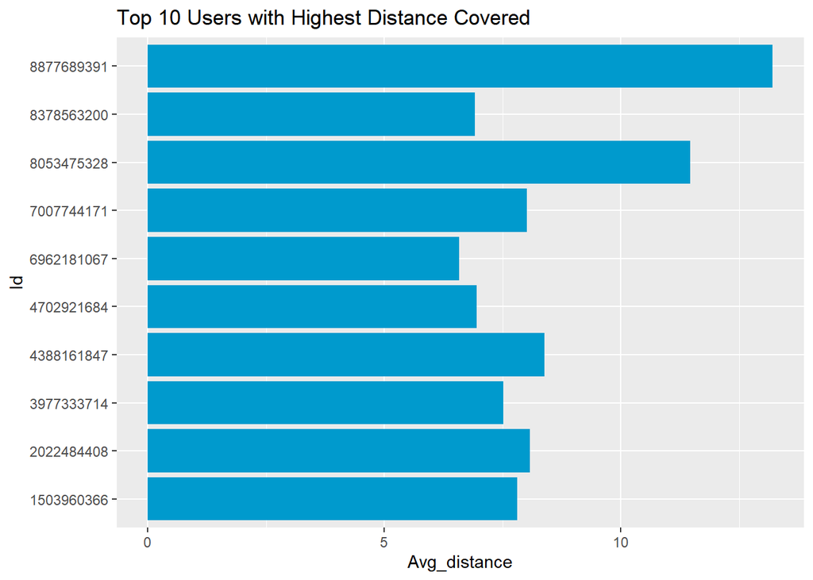

```r
top_dist_users <- average_activity %>%
       arrange(desc(Avg_distance)) %>%
       slice(1:10) %>%
       ggplot(., aes(x = Id, y=Avg_distance)) +
       geom_bar(stat="identity", fill="deepskyblue3") +
       ggtitle('Top 10 Users with Highest Distance Covered')
top_dist_users + coord_flip()
```

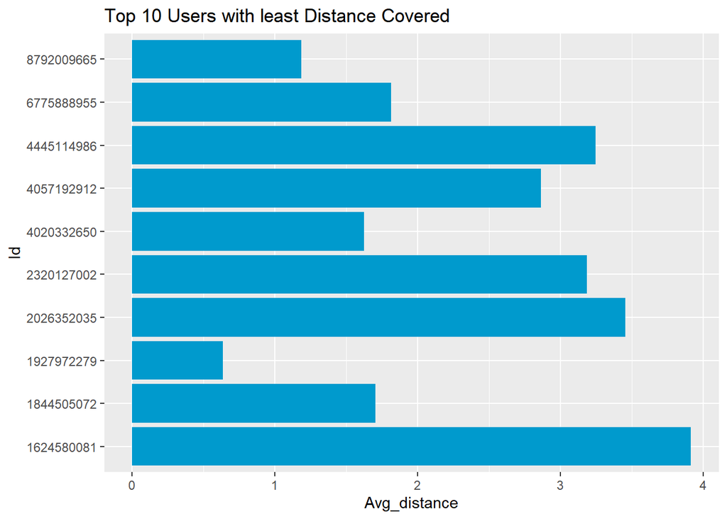

```r
least_dist_users <- average_activity %>%
       arrange(Avg_distance) %>%
       slice(1:10) %>%
       ggplot(., aes(x = Id, y=Avg_distance)) +
       geom_bar(stat="identity", fill="deepskyblue3") +
       ggtitle('Top 10 Users with least Distance Covered')
least_dist_users + coord_flip()
```

### Average Calories users generated within the period

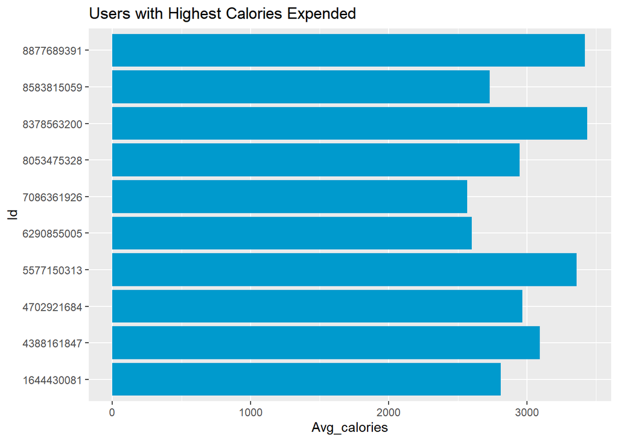

```r
avg_calories <- average_activity %>%
       arrange(desc(Avg_calories)) %>%
       slice(1:10) %>%
       ggplot(., aes(x = Id, y=Avg_calories)) +
       geom_bar(stat="identity", fill="deepskyblue3") +
       ggtitle('Users with Highest Calories Expended')
avg_calories + coord_flip()
```

*Top IDs burns an average between 2500 and 3500 calories on a daily basis*

### Average steps covered by users within the period

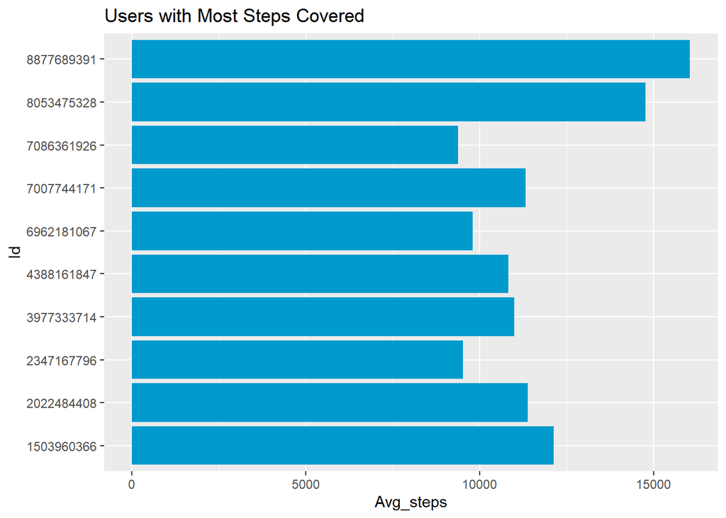

```r
avg_steps <- average_activity %>%
       arrange(desc(Avg_steps)) %>%
       slice(1:10) %>%
       ggplot(., aes(x = Id, y=Avg_steps)) +
       geom_bar(stat="identity", fill="deepskyblue3") +
       ggtitle('Users with Most Steps Covered')
avg_steps + coord_flip()
```

*For users with most steps, a minimal average of 9000 steps is taken on a daily basis*

### Understanding daily steps, distance covered and calories burnt within the period

```r
daily_activities <- daily_activity %>%
                      group_by(Date) %>%
                      summarise(daily_distance = mean(TotalDistance), daily_steps = mean(TotalSteps),
                      daily_calories = mean(Calories))
head(daily_activities)
```

```
## # A tibble: 6 × 4
##   Date       daily_distance daily_steps daily_calories
##   <date>              <dbl>       <dbl>          <dbl>
## 1 2016-04-12           5.98       8237.          2391.
## 2 2016-04-13           5.10       7199.          2287.
## 3 2016-04-14           5.60       7744.          2356.
## 4 2016-04-15           5.29       7534.          2355.
## 5 2016-04-16           6.29       8679.          2393.
## 6 2016-04-17           4.54       6409.          2231.
```

### Daily distance covered

```r
daily_dist_covered <- ggplot(daily_activities, aes(x=Date, y=daily_distance,)) +
  geom_line(size = 1.4)+
  ggtitle("Daily Distance Covered")+
  xlab("Date")+
  scale_x_date(date_labels="%b %d", date_breaks = "4 day")
  ylim(0,10)
```

```
## <ScaleContinuousPosition>
##  Range:
##  Limits:    0 --   10
```

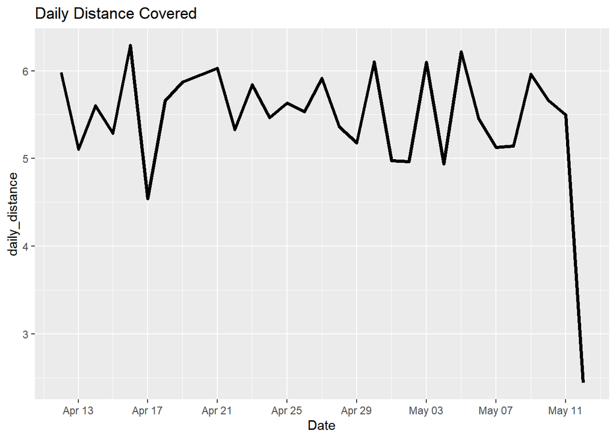

```r
daily_dist_covered
```

### daily steps covered

```r
daily_steps_covered <- ggplot(daily_activities, aes(x=Date, y=daily_steps,)) +
  geom_line(size = 1.4)+
  ggtitle("Daily Steps Covered")+
  xlab("Date")+
  scale_x_date(date_labels="%b %d", date_breaks = "4 day")
  ylim(5000,8500)
```

```
## <ScaleContinuousPosition>
##  Range:
##  Limits: 5e+03 -- 8.5e+03
```

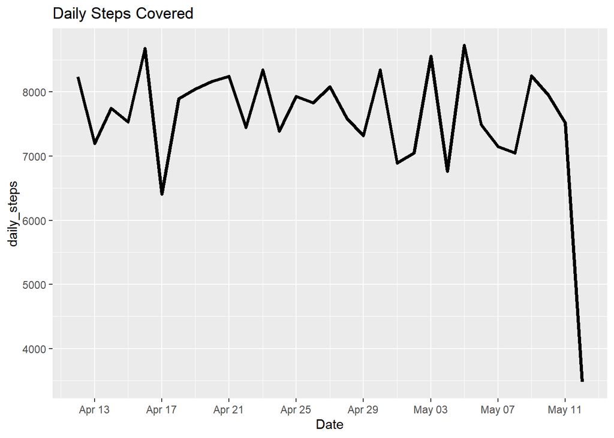

```r
daily_steps_covered
```

### Daily calories burnt

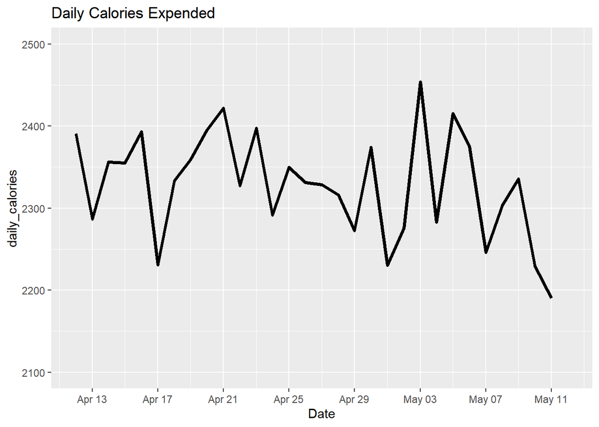

```r
daily_calories <- ggplot(daily_activities, aes(x=Date, y=daily_calories,)) +
  geom_line(size = 1.4)+
  ggtitle("Daily Calories Expended")+
  xlab("Date")+
  scale_x_date(date_labels="%b %d", date_breaks = "4 day")+
  ylim(2100,2500)
daily_calories
```

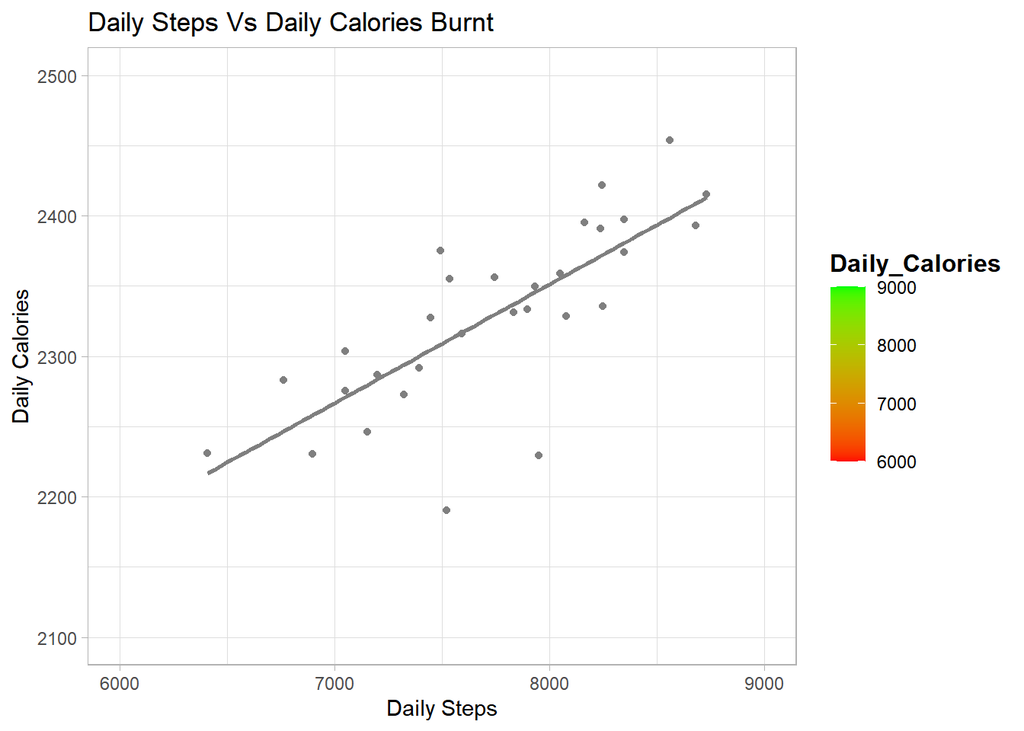

```r
steps_calories <- daily_activities %>%
  ggplot(aes(x = daily_steps, y = daily_calories, color = daily_calories)) +
  geom_point() +
  geom_smooth(method = "lm", color = "gray50", se = FALSE, size = 1) +
  ggtitle("Daily Steps Vs Daily Calories Burnt") +
  xlab("Daily Steps") +
  ylab("Daily Calories") +
  scale_color_gradient(low = "red", high = "green", limits = c(6000, 9000)) +
  guides(color = guide_colorbar(title = "Daily_Calories")) +
  xlim(6000, 9000)+
  ylim(2100,2500)+
  theme_light() +
  theme(legend.title = element_text(size = 12, face = "bold")) +
  theme(plot.caption = element_text(hjust = 0, margin = margin(t = 10)))
steps_calories
```

*The above charts reveals there exist a relationship between steps taken and calories expended on a daily basis.*

### Understaning the weight and BMI of different IDs and classifying them into categories to know number of persons under each category.

```r
weight_info <- weightlog_info %>%
                      group_by(Id) %>%
                      summarise(Avg_weight = mean(WeightKg),Avg_BMI = mean(BMI))
head(weight_info)
```

```
## # A tibble: 6 × 3
##   Id         Avg_weight Avg_BMI
##   <chr>           <dbl>   <dbl>
## 1 1503960366       52.6    22.6
## 2 1927972279      134.     47.5
## 3 2873212765       57      21.6
## 4 4319703577       72.4    27.4
## 5 4558609924       69.6    27.2
## 6 5577150313       90.7    28
```

### Adding a new column to determine IDs that are underweight, healthy, overweight and obese

```r
weight_info$Weight_status <- with(weight_info, ifelse(Avg_BMI > 30.0, 'obese',
                         ifelse(Avg_BMI > 25, 'overweight',
                         ifelse(Avg_BMI > 18, 'healthy', 'underweight'))))
head(weight_info)
```

```
## # A tibble: 6 × 4
##   Id         Avg_weight Avg_BMI Weight_status
##   <chr>           <dbl>   <dbl> <chr>
## 1 1503960366       52.6    22.6 healthy
## 2 1927972279      134.     47.5 obese
## 3 2873212765       57      21.6 healthy
## 4 4319703577       72.4    27.4 overweight
## 5 4558609924       69.6    27.2 overweight
## 6 5577150313       90.7    28   overweight
```

### Average weight Vs BMI to show the relationship

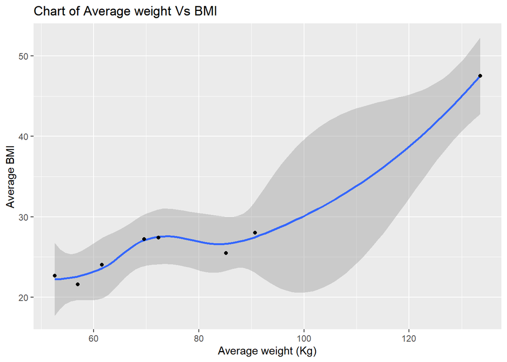

```r
Weight_BMI <- ggplot(data = weight_info) + geom_smooth(mapping = aes(x=Avg_weight, y=Avg_BMI)) +
  geom_point(mapping = aes(x=Avg_weight, y=Avg_BMI)) +
  labs(title = "Chart of Average weight Vs BMI", x = "Average weight (Kg)", y = "Average BMI")
Weight_BMI
```

### Visualising to Know different weight status of the IDs

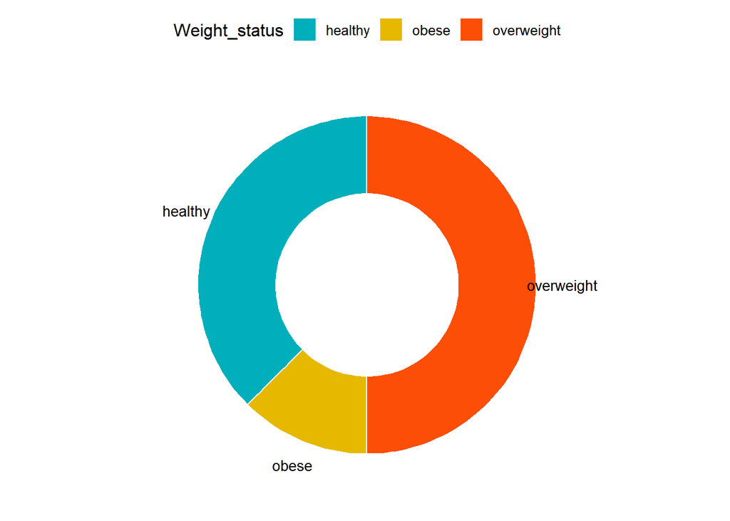

```r
weight_info %>%
  pull(Weight_status) %>%
  fct_count() %>%
  rename(Weight_status = f, count = n) %>%
  ggdonutchart("count", label = "Weight_status", fill = "Weight_status", color = "white",
               palette = c("#00AFBB", "#E7B800", "#FC4E07"))
```

*The data reveals that 50% of the users are overweight while 35% are healthy and the other 15% are obese using their BMI status.*

### Determining relationship between sleep and activities

```r
activity_df <- daily_activity%>%
                  select(Id, Date, TotalSteps, VeryActiveMinutes, Calories)
colnames(activity_df)
```

```
## [1] "Id"                "Date"              "TotalSteps"
## [4] "VeryActiveMinutes" "Calories"
```

```r
colnames(sleepday)
```

```
## [1] "Id"                 "Date"               "TotalSleepRecords"
## [4] "TotalMinutesAsleep" "TotalTimeInBed"
```

### Merging two dataframes usig common columns

```r
activity_sleep <- merge(activity_df, sleepday, by = c("Id", "Date"))
head(activity_sleep)
```

```
##           Id       Date TotalSteps VeryActiveMinutes Calories TotalSleepRecords
## 1 1503960366 2016-04-12      13162                25     1985                 1
## 2 1503960366 2016-04-13      10735                21     1797                 2
## 3 1503960366 2016-04-15       9762                29     1745                 1
## 4 1503960366 2016-04-16      12669                36     1863                 2
## 5 1503960366 2016-04-17       9705                38     1728                 1
## 6 1503960366 2016-04-19      15506                50     2035                 1
##   TotalMinutesAsleep TotalTimeInBed
## 1                327            346
## 2                384            407
## 3                412            442
## 4                340            367
## 5                700            712
## 6                304            320
```

### Adding a new column to cater for non sleeping time while in bed

```r
activity_sleep <- activity_sleep %>%
           mutate(NonSleepTimeInBed = TotalTimeInBed - TotalMinutesAsleep)
head(activity_sleep)
```

```
##           Id       Date TotalSteps VeryActiveMinutes Calories TotalSleepRecords
## 1 1503960366 2016-04-12      13162                25     1985                 1
## 2 1503960366 2016-04-13      10735                21     1797                 2
## 3 1503960366 2016-04-15       9762                29     1745                 1
## 4 1503960366 2016-04-16      12669                36     1863                 2
## 5 1503960366 2016-04-17       9705                38     1728                 1
## 6 1503960366 2016-04-19      15506                50     2035                 1
##   TotalMinutesAsleep TotalTimeInBed NonSleepTimeInBed
## 1                327            346                19
## 2                384            407                23
## 3                412            442                30
## 4                340            367                27
## 5                700            712                12
## 6                304            320                16
```

### Use correlation to check if there is any relationship

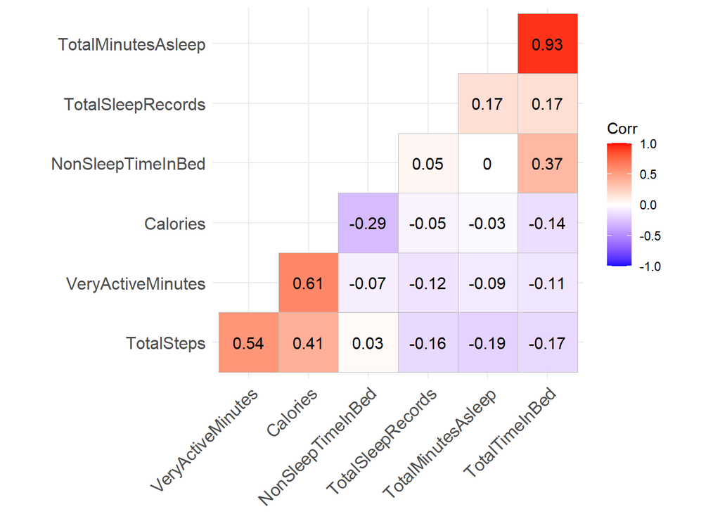

```r
corr_activity_sleep <- dplyr::select(activity_sleep,-c("Id","Date"))
corr <- round(cor(corr_activity_sleep),3)
ggcorrplot(corr, hc.order = TRUE, type = "lower", lab = TRUE)
```

*The correlation chart buttresses further the relationship between steps taken and calories expended by users on a day to day basics.*

*Also, people with active minutes has a strong correlation with calories burn.*

*There is no correlation between total minutes asleep and calories burn by users.*

### Checking for ActiveMinutes and Calories Burnt

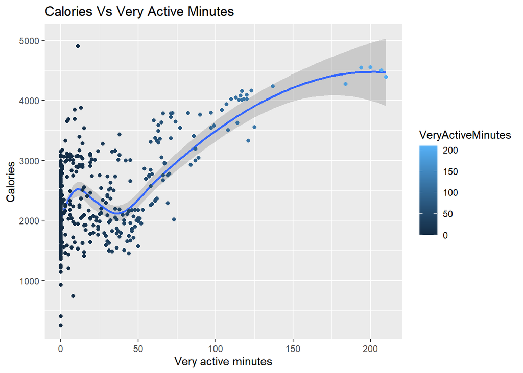

```r
ggplot(data = activity_sleep) + geom_smooth(mapping = aes(x=VeryActiveMinutes, y=Calories)) +
  geom_point(mapping = aes(x=VeryActiveMinutes, y=Calories, color = VeryActiveMinutes)) +
  labs(title = "Calories Vs Very Active Minutes", x = "Very active minutes", y = "Calories")
```

*It reveals further that people with more active time burn more calories than than those with minimal time.*

### Checking for relationsship NonSleepTimeInBed and Calories

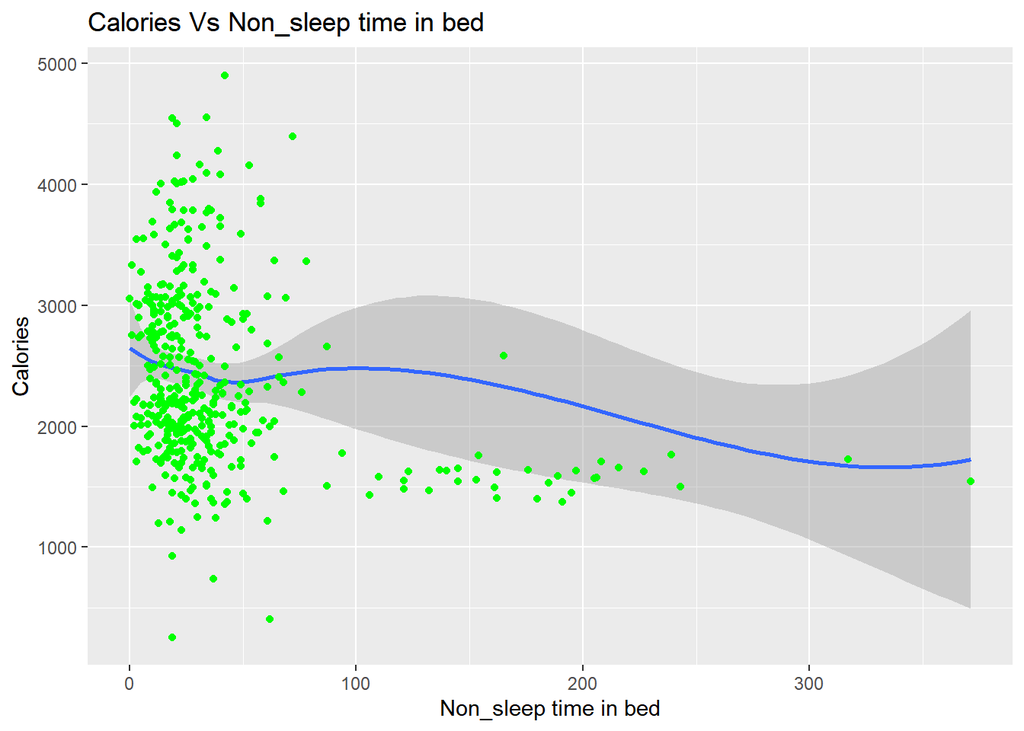

```r
ggplot(data = activity_sleep) + geom_smooth(mapping = aes(x=NonSleepTimeInBed, y=Calories)) +
  geom_point(mapping = aes(x=NonSleepTimeInBed, y=Calories), color = "green") +
  labs(title = "Calories Vs Non_sleep time in bed", x = "Non_sleep time in bed", y = "Calories")
```

### Merging the heartrate df to the activity_sleep data to know if any relationship exist amongst the data.

```r
heartrate <- heartrate %>%
            group_by(Id, Date) %>%
                      summarise(daily_heartrate = mean(Value))
```

[output not shown]

```r
head(heartrate)
```

```
## # A tibble: 6 × 3
## # Groups:   Id [1]
##   Id         Date       daily_heartrate
##   <chr>      <date>               <dbl>
## 1 2022484408 2016-04-12            75.8
## 2 2022484408 2016-04-13            80.3
## 3 2022484408 2016-04-14            72.6
## 4 2022484408 2016-04-15            80.4
## 5 2022484408 2016-04-16            76.0
## 6 2022484408 2016-04-17            83.9
```

```r
activity_sleep_heartrate <- merge(activity_sleep, heartrate, by = c("Id", "Date"))
head(activity_sleep_heartrate)
```

```
##           Id       Date TotalSteps VeryActiveMinutes Calories TotalSleepRecords
## 1 2026352035 2016-04-17        838                 0     1214                 1
## 2 2026352035 2016-04-25       6017                 0     1576                 1
## 3 2026352035 2016-05-02       7018                 0     1690                 1
## 4 2026352035 2016-05-09      10685                 0     1869                 1
## 5 2347167796 2016-04-13      10352                19     2038                 1
## 6 2347167796 2016-04-14      10129                 1     2010                 1
##   TotalMinutesAsleep TotalTimeInBed NonSleepTimeInBed daily_heartrate
## 1                437            498                61        68.65625
## 2                506            531                25        99.50581
## 3                511            543                32        84.13457
## 4                531            556                25        98.23390
## 5                467            531                64        73.81290
## 6                445            489                44        72.57948
```

### Checking the correlation

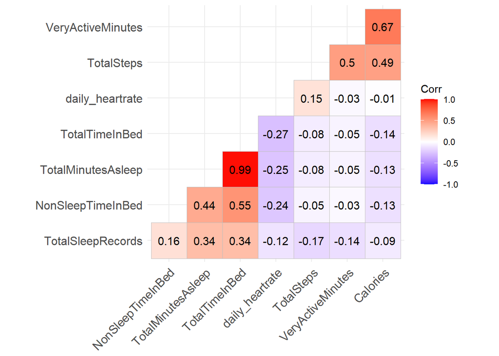

```r
corr_activity_sleep_heartrate <- dplyr::select(activity_sleep_heartrate,-c("Id","Date"))
corr <- round(cor(corr_activity_sleep_heartrate),3)
ggcorrplot(corr, hc.order = TRUE, type = "lower", lab = TRUE)
```

*The daily heartrate has no correlation with active minutes & total steps meanwhile shows a -ve correlation for total time in bed, minutes asleep & non sleep time in bed*

### Relationship between Total Minutes Asleep & daily heartrate

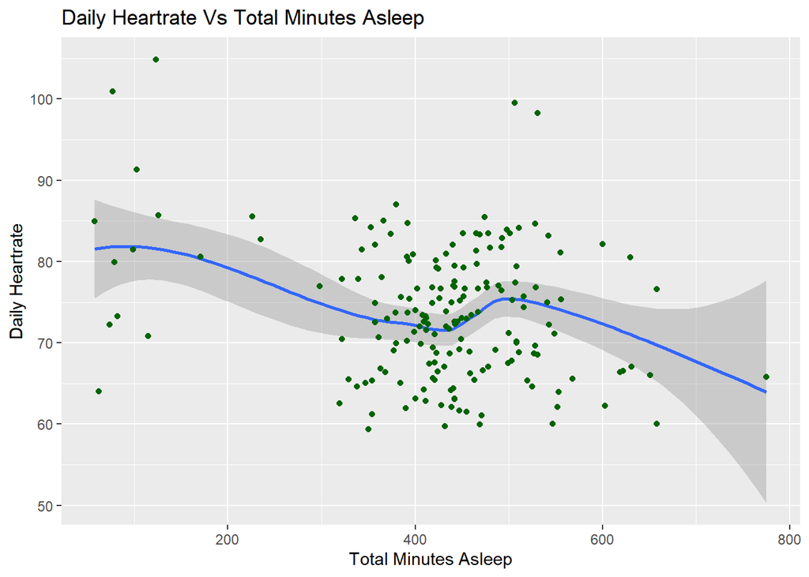

```r
ggplot(data = activity_sleep_heartrate) + geom_smooth(mapping = aes(x=TotalMinutesAsleep, y=daily_heartrate)) +
  geom_point(mapping = aes(x=TotalMinutesAsleep, y=daily_heartrate), color = "darkgreen") +
  labs(title = "Daily Heartrate Vs Total Minutes Asleep", x = "Total Minutes Asleep", y = "Daily Heartrate")
```

*The chart shows that despite the number of time spent asleep on a daily basis, has no impact on the heart beat rate.*

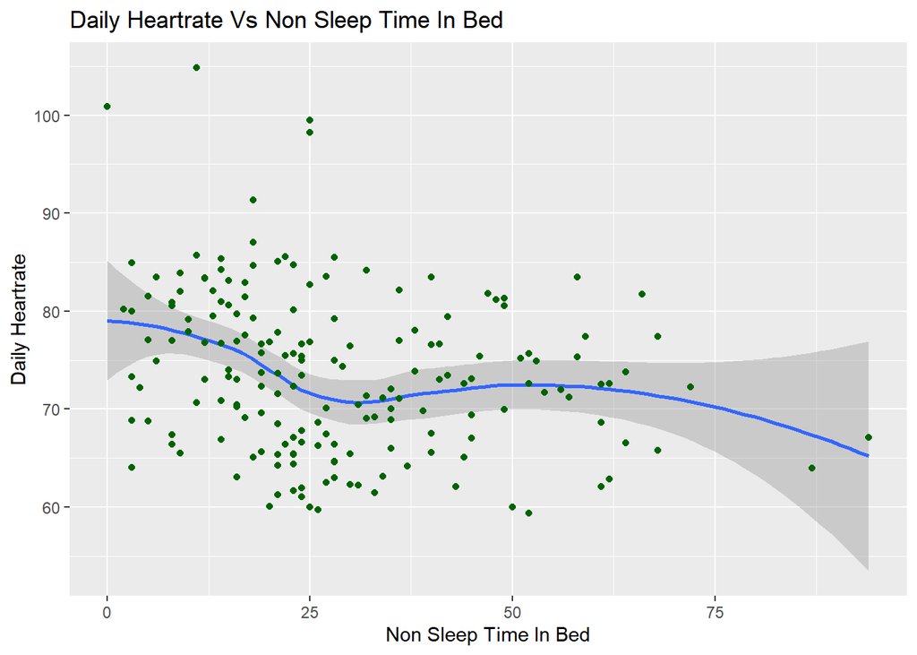

```r
ggplot(data = activity_sleep_heartrate) + geom_smooth(mapping = aes(x= NonSleepTimeInBed, y=daily_heartrate)) +
  geom_point(mapping = aes(x=NonSleepTimeInBed, y=daily_heartrate), color = "darkgreen") +
  labs(title = "Daily Heartrate Vs Non Sleep Time In Bed", x = "Non Sleep Time In Bed", y = "Daily Heartrate")
```

*No clear relationship existing between non sleeping time in bed and daily heartrate.*

## Recommendatons

- The data set available are limited to get a more comprehensive analysis and the need to gather more data set for a longer period of time is necessary.
- Customers can get a monthly report of their calories, health status using BMI or weight & other vitals as email to show accountability & progress they make. Perks like this can make Bella bet stand out.
- Create discount for users that introduce a new customer.
- Introduce products/activities that will target users that are overweight to burn more calories & create personalized services since most users are in this categories.
- Create more awareness across digital platforms & also work with health centers to have access to new mothers that will need the product.
- Quarterly reports should be made available to the public on media spaces for general awareness & benefits of the product.